# Project Title : Bootcamp Akademi, Phase1 Projet final

## Overview

Ce projet s’inscrit dans le cadre du programme de Data Sciences de Bootcamp Akademi, et marque la fin de la première phase de la formation. Il a pour objectif de tester ma compréhension et ma maîtrise des notions abordées durant cette phase.

Le projet couvre les thématiques suivantes :

Pandas : manipulation et nettoyage de données

Data Visualization : représentation graphique des données pour en faciliter l’analyse

Exploring Statistical Data : exploration et interprétation de données statistiques

Python Data Structures : utilisation des structures de données fondamentales en Python

À travers ce projet, j’ai appliqué les compétences acquises pour analyser un jeu de données réel, en mettant l’accent sur la rigueur, l’interprétation des résultats et la qualité des visualisations.

## Business Problem

L'entreprise se développe dans de nouveaux secteurs afin de diversifier son portefeuille. Elle souhaite notamment acquérir et exploiter des avions pour des entreprises commerciales et privées, mais ignore les risques potentiels liés à l'aviation. Je suis chargé d'identifier les avions présentant le moins de risques pour l'entreprise lors du lancement de cette nouvelle activité. Je dois ensuite traduiremes conclusions en informations exploitables que le responsable de la nouvelle division aéronautique pourra utiliser pour l'aider à choisir les avions à acquérir.

```python
# Importons les librairies
import pandas as pd
import numpy as np
from numbers import Number
import matplotlib.pyplot as plt
import seaborn as sns
import plotly.express as px
import warnings
warnings.filterwarnings('ignore')
```

## Data Understanding

Nous allons utiliser pandas pour créer un nouveau DataFrame, appelé df, contenant les données de l'ensemble de données dans le fichier Aviation_Data.csv

```python
# Lecture du fichier
df = pd.read_csv("AviationData.csv", encoding = "mac_roman ")
```

```
       Structure générale du dataset
```

```python
df.shape # info sur la dimension du dataset
df.shape
```

```
(88889, 31)
```

```
   Le dataset contient 88889 lignes et 31 colonnes
```

```python
df.dtypes      # Types de données
```

```
Event.Id                   object
Investigation.Type         object
Accident.Number            object
Event.Date                 object
Location                   object
Country                    object
Latitude                   object
Longitude                  object
Airport.Code               object
Airport.Name               object
Injury.Severity            object
Aircraft.damage            object
Aircraft.Category          object
Registration.Number        object
Make                       object
Model                      object
Amateur.Built              object
Number.of.Engines         float64
Engine.Type                object
FAR.Description            object
Schedule                   object
Purpose.of.flight          object
Air.carrier                object
Total.Fatal.Injuries      float64
Total.Serious.Injuries    float64
Total.Minor.Injuries      float64
Total.Uninjured           float64
Weather.Condition          object
Broad.phase.of.flight      object
Report.Status              object
Publication.Date           object
dtype: object
```

Nous avons 5 colonnes de type float et les autres sont de type object, toutefois, nous aurons à faire des conversions, c'est le cas par exemple des colonnes: Event.Date; Publication.Date qui doivent etre de type "datetime".

```python
df.head(10)      # Aperçu des 10 premières lignes
```

|  | Event.Id | Investigation.Type | Accident.Number | Event.Date | Location | Country | Latitude | Longitude | Airport.Code | Airport.Name | ... | Purpose.of.flight | Air.carrier | Total.Fatal.Injuries | Total.Serious.Injuries | Total.Minor.Injuries | Total.Uninjured | Weather.Condition | Broad.phase.of.flight | Report.Status | Publication.Date |
| --- | --- | --- | --- | --- | --- | --- | --- | --- | --- | --- | --- | --- | --- | --- | --- | --- | --- | --- | --- | --- | --- |
| 0 | 20001218X45444 | Accident | SEA87LA080 | 1948-10-24 | MOOSE CREEK, ID | United States | NaN | NaN | NaN | NaN | ... | Personal | NaN | 2.0 | 0.0 | 0.0 | 0.0 | UNK | Cruise | Probable Cause | NaN |
| 1 | 20001218X45447 | Accident | LAX94LA336 | 1962-07-19 | BRIDGEPORT, CA | United States | NaN | NaN | NaN | NaN | ... | Personal | NaN | 4.0 | 0.0 | 0.0 | 0.0 | UNK | Unknown | Probable Cause | 19-09-1996 |
| 2 | 20061025X01555 | Accident | NYC07LA005 | 1974-08-30 | Saltville, VA | United States | 36.922223 | -81.878056 | NaN | NaN | ... | Personal | NaN | 3.0 | NaN | NaN | NaN | IMC | Cruise | Probable Cause | 26-02-2007 |
| 3 | 20001218X45448 | Accident | LAX96LA321 | 1977-06-19 | EUREKA, CA | United States | NaN | NaN | NaN | NaN | ... | Personal | NaN | 2.0 | 0.0 | 0.0 | 0.0 | IMC | Cruise | Probable Cause | 12-09-2000 |
| 4 | 20041105X01764 | Accident | CHI79FA064 | 1979-08-02 | Canton, OH | United States | NaN | NaN | NaN | NaN | ... | Personal | NaN | 1.0 | 2.0 | NaN | 0.0 | VMC | Approach | Probable Cause | 16-04-1980 |
| 5 | 20170710X52551 | Accident | NYC79AA106 | 1979-09-17 | BOSTON, MA | United States | 42.445277 | -70.758333 | NaN | NaN | ... | NaN | Air Canada | NaN | NaN | 1.0 | 44.0 | VMC | Climb | Probable Cause | 19-09-2017 |
| 6 | 20001218X45446 | Accident | CHI81LA106 | 1981-08-01 | COTTON, MN | United States | NaN | NaN | NaN | NaN | ... | Personal | NaN | 4.0 | 0.0 | 0.0 | 0.0 | IMC | Unknown | Probable Cause | 06-11-2001 |
| 7 | 20020909X01562 | Accident | SEA82DA022 | 1982-01-01 | PULLMAN, WA | United States | NaN | NaN | NaN | BLACKBURN AG STRIP | ... | Personal | NaN | 0.0 | 0.0 | 0.0 | 2.0 | VMC | Takeoff | Probable Cause | 01-01-1982 |
| 8 | 20020909X01561 | Accident | NYC82DA015 | 1982-01-01 | EAST HANOVER, NJ | United States | NaN | NaN | N58 | HANOVER | ... | Business | NaN | 0.0 | 0.0 | 0.0 | 2.0 | IMC | Landing | Probable Cause | 01-01-1982 |
| 9 | 20020909X01560 | Accident | MIA82DA029 | 1982-01-01 | JACKSONVILLE, FL | United States | NaN | NaN | JAX | JACKSONVILLE INTL | ... | Personal | NaN | 0.0 | 0.0 | 3.0 | 0.0 | IMC | Cruise | Probable Cause | 01-01-1982 |

10 rows × 31 columns

```python
df.tail(10)      # Aperçu des 10 dernières lignes
```

|  | Event.Id | Investigation.Type | Accident.Number | Event.Date | Location | Country | Latitude | Longitude | Airport.Code | Airport.Name | ... | Purpose.of.flight | Air.carrier | Total.Fatal.Injuries | Total.Serious.Injuries | Total.Minor.Injuries | Total.Uninjured | Weather.Condition | Broad.phase.of.flight | Report.Status | Publication.Date |
| --- | --- | --- | --- | --- | --- | --- | --- | --- | --- | --- | --- | --- | --- | --- | --- | --- | --- | --- | --- | --- | --- |
| 88879 | 20221219106472 | Accident | DCA23LA096 | 2022-12-18 | Kahului, HI | United States | NaN | NaN | NaN | NaN | ... | NaN | HAWAIIAN AIRLINES INC | 0.0 | 0.0 | 0.0 | 0.0 | NaN | NaN | NaN | NaN |
| 88880 | 20221219106477 | Accident | WPR23LA071 | 2022-12-18 | San Manual, AZ | United States | NaN | NaN | NaN | NaN | ... | Personal | Chandler Air Service | 0.0 | 0.0 | 0.0 | 3.0 | NaN | NaN | NaN | 20-12-2022 |
| 88881 | 20221221106483 | Accident | CEN23LA067 | 2022-12-21 | Auburn Hills, MI | United States | NaN | NaN | NaN | NaN | ... | Personal | Pilot | 0.0 | 1.0 | 0.0 | 0.0 | NaN | NaN | NaN | 22-12-2022 |
| 88882 | 20221222106486 | Accident | CEN23LA068 | 2022-12-21 | Reserve, LA | United States | NaN | NaN | NaN | NaN | ... | Instructional | NaN | 0.0 | 1.0 | 0.0 | 1.0 | NaN | NaN | NaN | 27-12-2022 |
| 88883 | 20221228106502 | Accident | GAA23WA046 | 2022-12-22 | Brasnorte, | Brazil | NaN | NaN | NaN | NaN | ... | NaN | NaN | 1.0 | 0.0 | 0.0 | 0.0 | NaN | NaN | NaN | 28-12-2022 |
| 88884 | 20221227106491 | Accident | ERA23LA093 | 2022-12-26 | Annapolis, MD | United States | NaN | NaN | NaN | NaN | ... | Personal | NaN | 0.0 | 1.0 | 0.0 | 0.0 | NaN | NaN | NaN | 29-12-2022 |
| 88885 | 20221227106494 | Accident | ERA23LA095 | 2022-12-26 | Hampton, NH | United States | NaN | NaN | NaN | NaN | ... | NaN | NaN | 0.0 | 0.0 | 0.0 | 0.0 | NaN | NaN | NaN | NaN |
| 88886 | 20221227106497 | Accident | WPR23LA075 | 2022-12-26 | Payson, AZ | United States | 341525N | 1112021W | PAN | PAYSON | ... | Personal | NaN | 0.0 | 0.0 | 0.0 | 1.0 | VMC | NaN | NaN | 27-12-2022 |
| 88887 | 20221227106498 | Accident | WPR23LA076 | 2022-12-26 | Morgan, UT | United States | NaN | NaN | NaN | NaN | ... | Personal | MC CESSNA 210N LLC | 0.0 | 0.0 | 0.0 | 0.0 | NaN | NaN | NaN | NaN |
| 88888 | 20221230106513 | Accident | ERA23LA097 | 2022-12-29 | Athens, GA | United States | NaN | NaN | NaN | NaN | ... | Personal | NaN | 0.0 | 1.0 | 0.0 | 1.0 | NaN | NaN | NaN | 30-12-2022 |

10 rows × 31 columns

```python
df.info()      # Infos sur les colonnes, types, et valeurs manquantes
```

```
<class 'pandas.core.frame.DataFrame'>
RangeIndex: 88889 entries, 0 to 88888
Data columns (total 31 columns):
 #   Column                  Non-Null Count  Dtype
---  ------                  --------------  -----
 0   Event.Id                88889 non-null  object
 1   Investigation.Type      88889 non-null  object
 2   Accident.Number         88889 non-null  object
 3   Event.Date              88889 non-null  object
 4   Location                88837 non-null  object
 5   Country                 88663 non-null  object
 6   Latitude                34382 non-null  object
 7   Longitude               34373 non-null  object
 8   Airport.Code            50132 non-null  object
 9   Airport.Name            52704 non-null  object
```

[output cut: 23 more lines]

```python
#Vérification du nombre de valeurs manquantes dans chaque colonne
df.isna().sum()
```

```
Event.Id                      0
Investigation.Type            0
Accident.Number               0
Event.Date                    0
Location                     52
Country                     226
Latitude                  54507
Longitude                 54516
Airport.Code              38757
Airport.Name              36185
Injury.Severity            1000
Aircraft.damage            3194
Aircraft.Category         56602
Registration.Number        1382
Make                         63
Model                        92
Amateur.Built               102
Number.of.Engines          6084
Engine.Type                7096
FAR.Description           56866
Schedule                  76307
Purpose.of.flight          6192
Air.carrier               72241
Total.Fatal.Injuries      11401
Total.Serious.Injuries    12510
Total.Minor.Injuries      11933
Total.Uninjured            5912
Weather.Condition          4492
Broad.phase.of.flight     27165
Report.Status              6384
Publication.Date          13771
dtype: int64
```

Commentaire: On remarque un grand nombre de colonnes présentant des valeurs manquantes.

```python
# Verifions la colonnes Investigation.Type
df['Investigation.Type'].value_counts()
```

```
Investigation.Type
Accident    85015
Incident     3874
Name: count, dtype: int64
```

Nous allons considerer à la fois les incidents et les accidents.

## Data Preparation

Étant donné que chaque événement est identifié par un ID, les valeurs de la colonne Event.Id représentent des clés primaires pour les lignes. Elles doivent donc être uniques. Nous allons donc vérifier la présence éventuelle de doublons.

```python
# Vérifions s’il y a des doublons dans la colonne Event.Id.
df['Event.Id'].nunique() # affichons les valeurs uniques de la colonne Event.Id
```

```
87951
```

Notre dataset contient 88 889 lignes. Étant donné que la colonne Event.Id compte 87 951 valeurs uniques, cela signifie qu'elle comporte des doublons.

```
Affichons uniquement les lignes contenant des doublons dans la colonne Event.Id.
```

```python
df[df.duplicated(subset='Event.Id', keep=False)]
```

|  | Event.Id | Investigation.Type | Accident.Number | Event.Date | Location | Country | Latitude | Longitude | Airport.Code | Airport.Name | ... | Purpose.of.flight | Air.carrier | Total.Fatal.Injuries | Total.Serious.Injuries | Total.Minor.Injuries | Total.Uninjured | Weather.Condition | Broad.phase.of.flight | Report.Status | Publication.Date |
| --- | --- | --- | --- | --- | --- | --- | --- | --- | --- | --- | --- | --- | --- | --- | --- | --- | --- | --- | --- | --- | --- |
| 117 | 20020917X01908 | Accident | DCA82AA012B | 1982-01-19 | ROCKPORT, TX | United States | NaN | NaN | RKP | ARANSAS COUNTY AIRPORT | ... | Personal | NaN | 3.0 | 0.0 | 0.0 | 0.0 | IMC | Approach | Probable Cause | 19-01-1983 |
| 118 | 20020917X01908 | Accident | DCA82AA012A | 1982-01-19 | ROCKPORT, TX | United States | NaN | NaN | RKP | ARANSAS COUNTY AIRPORT | ... | Executive/corporate | NaN | 3.0 | 0.0 | 0.0 | 0.0 | IMC | Approach | Probable Cause | 19-01-1983 |
| 153 | 20020917X02259 | Accident | LAX82FA049A | 1982-01-23 | VICTORVILLE, CA | United States | NaN | NaN | NaN | NaN | ... | Personal | NaN | 2.0 | 0.0 | 4.0 | 0.0 | VMC | Unknown | Probable Cause | 23-01-1983 |
| 158 | 20020917X02400 | Accident | MIA82FA038B | 1982-01-23 | NEWPORT RICHEY, FL | United States | NaN | NaN | NaN | NaN | ... | Personal | NaN | 0.0 | 0.0 | 0.0 | 3.0 | VMC | Cruise | Probable Cause | 23-01-1983 |
| 159 | 20020917X02400 | Accident | MIA82FA038A | 1982-01-23 | NEWPORT RICHEY, FL | United States | NaN | NaN | NaN | NaN | ... | Personal | NaN | 0.0 | 0.0 | 0.0 | 3.0 | VMC | Approach | Probable Cause | 23-01-1983 |
| ... | ... | ... | ... | ... | ... | ... | ... | ... | ... | ... | ... | ... | ... | ... | ... | ... | ... | ... | ... | ... | ... |
| 88796 | 20221121106336 | Accident | WPR23LA041 | 2022-11-18 | Las Vegas, NV | United States | 361239N | 1151140W | VGT | NORTH LAS VEGAS | ... | Instructional | 702 HELICOPTER INC | 0.0 | 0.0 | 0.0 | 3.0 | VMC | NaN | NaN | 07-12-2022 |
| 88797 | 20221122106340 | Incident | DCA23WA071 | 2022-11-18 | Marrakech, | Morocco | NaN | NaN | NaN | NaN | ... | NaN | British Airways | 0.0 | 0.0 | 0.0 | 0.0 | NaN | NaN | NaN | NaN |
| 88798 | 20221122106340 | Incident | DCA23WA071 | 2022-11-18 | Marrakech, | Morocco | NaN | NaN | NaN | NaN | ... | NaN | Valair Private Jets | 0.0 | 0.0 | 0.0 | 0.0 | NaN | NaN | NaN | NaN |
| 88813 | 20221123106354 | Accident | WPR23LA045 | 2022-11-22 | San Diego, CA | United States | 323414N | 1165825W | SDM | Brown Field Municipal Airport | ... | Instructional | HeliStream Inc. | 0.0 | 0.0 | 0.0 | 4.0 | VMC | NaN | NaN | 22-12-2022 |
| 88814 | 20221123106354 | Accident | WPR23LA045 | 2022-11-22 | San Diego, CA | United States | 323414N | 1165825W | SDM | Brown Field Municipal Airport | ... | Public Aircraft - Federal | U.S. Navy | 0.0 | 0.0 | 0.0 | 4.0 | VMC | NaN | NaN | 22-12-2022 |

1874 rows × 31 columns

L’affichage confirme effectivement la présence de lignes de données qui se répètent.

```
   Supprimons les doublons
```

```python
df = df.drop_duplicates(subset='Event.Id', keep='first')
```

```python
df.info()
```

```
<class 'pandas.core.frame.DataFrame'>
Index: 87951 entries, 0 to 88888
Data columns (total 31 columns):
 #   Column                  Non-Null Count  Dtype
---  ------                  --------------  -----
 0   Event.Id                87951 non-null  object
 1   Investigation.Type      87951 non-null  object
 2   Accident.Number         87951 non-null  object
 3   Event.Date              87951 non-null  object
 4   Location                87899 non-null  object
 5   Country                 87729 non-null  object
 6   Latitude                34212 non-null  object
 7   Longitude               34203 non-null  object
 8   Airport.Code            49484 non-null  object
 9   Airport.Name            52031 non-null  object
```

[output cut: 23 more lines]

La colonne Event.Date est actuellement de type object. Convertissons-la en type datetime afin de faciliter les traitements liés aux dates.

```python
df['Event.Date'] = pd.to_datetime(df['Event.Date'], errors='coerce')
```

```python
print(df['Event.Date'].dtype)  # Doit afficher: datetime64[ns]
print(df['Event.Date'].head()) # Affiche les premières dates
print("Valeurs non converties (NaT) :", df['Event.Date'].isna().sum())
```

```
datetime64[ns]
0   1948-10-24
1   1962-07-19
2   1974-08-30
3   1977-06-19
4   1979-08-02
Name: Event.Date, dtype: datetime64[ns]
Valeurs non converties (NaT) : 0
```

créons une nouvelle colonne appelée Event.Year qui contient l'année extraite de la date.

```python
#Définissons une colonne « Année » et affichons les années uniques
df["Event.Year"] = df.loc[:,("Event.Date")].dt.year
df["Event.Year"].unique()
```

```
array([1948, 1962, 1974, 1977, 1979, 1981, 1982, 1983, 1984, 1985, 1986,
       1987, 1988, 1989, 1990, 1991, 1992, 1993, 1994, 1995, 1996, 1997,
       1998, 1999, 2000, 2001, 2002, 2003, 2004, 2005, 2006, 2007, 2008,
       2009, 2010, 2011, 2012, 2013, 2014, 2015, 2016, 2017, 2018, 2019,
       2020, 2021, 2022])
```

Notre dataset couvre une période allant de l’année 1948 jusqu’à l’année 2022.

Uniformisons la casse dans les colonnes de type texte (Object) pour éviter les doublons invisibles causés par des majuscules/minuscules incohérentes.

```python
# Identifions les colonnes de type object
cat_cols = df.select_dtypes(include='object').columns

# Appliquons str.lower() à toutes ces colonnes
for col in cat_cols:
    df[col] = df[col].str.lower()
```

Supprimons les colonnes avec plus de 40 % de valeurs manquantes, cela nous permet de conserver uniquement les variables les plus exploitables.

```python
# Seuil de tolérance : 40% de valeurs manquantes
seuil = 0.4

# Calcul du pourcentage de valeurs manquantes pour chaque colonne
missing_ratio = df.isnull().mean()

# Filtrage des colonnes à conserver
columns_to_keep = missing_ratio[missing_ratio <= seuil].index

# Nouveau DataFrame avec uniquement les colonnes retenues
df = df[columns_to_keep]
```

```python
df.info()
```

```
<class 'pandas.core.frame.DataFrame'>
Index: 87951 entries, 0 to 88888
Data columns (total 24 columns):
 #   Column                  Non-Null Count  Dtype
---  ------                  --------------  -----
 0   Event.Id                87951 non-null  object
 1   Investigation.Type      87951 non-null  object
 2   Accident.Number         87951 non-null  object
 3   Event.Date              87951 non-null  datetime64[ns]
 4   Location                87899 non-null  object
 5   Country                 87729 non-null  object
 6   Injury.Severity         86961 non-null  object
 7   Aircraft.damage         84848 non-null  object
 8   Registration.Number     86601 non-null  object
 9   Make                    87888 non-null  object
```

[output cut: 16 more lines]

Certaines colonnes semblent peu pertinentes pour mon analyse, donc je les supprime afin de simplifier la gestion des données.

```python
columns_to_drop = [
    'Accident.Number',
    'Registration.Number',
    'Publication.Date',
    'Report.Status',
    'Event.Id',
    'Event.Date',
    'Location',
    'Country',
    'Injury.Severity',


]
df = df.drop(columns=columns_to_drop)
```

```python
df.info()
```

```
<class 'pandas.core.frame.DataFrame'>
Index: 87951 entries, 0 to 88888
Data columns (total 15 columns):
 #   Column                  Non-Null Count  Dtype
---  ------                  --------------  -----
 0   Investigation.Type      87951 non-null  object
 1   Aircraft.damage         84848 non-null  object
 2   Make                    87888 non-null  object
 3   Model                   87859 non-null  object
 4   Amateur.Built           87851 non-null  object
 5   Number.of.Engines       81924 non-null  float64
 6   Engine.Type             80908 non-null  object
 7   Purpose.of.flight       81829 non-null  object
 8   Total.Fatal.Injuries    76684 non-null  float64
 9   Total.Serious.Injuries  75629 non-null  float64
 10  Total.Minor.Injuries    76191 non-null  float64
 11  Total.Uninjured         82088 non-null  float64
 12  Weather.Condition       83478 non-null  object
 13  Broad.phase.of.flight   60837 non-null  object
 14  Event.Year              87951 non-null  int32
dtypes: float64(5), int32(1), object(9)
memory usage: 10.4+ MB
```

```python
# Affichons le nombre d'événements (accidents/incidents) enregistrés pour chaque année dans la colonne 'Year'
df['Event.Year'].value_counts()
```

```
Event.Year
1982    3547
1983    3513
1984    3406
1985    3053
1986    2832
1987    2773
1988    2685
1989    2502
1990    2480
1991    2420
1992    2328
1993    2285
1995    2278
1994    2229
```

[output cut: 34 more lines]

Observation : la majorité des événements (accident/incident) sont enregistrés à partir de 1982, avec très peu de cas avant cette date. Pour garantir une analyse plus représentative et éviter les biais liés à des années avec trop peu de données, nous allons restreindre notre analyse aux événements survenus à partir de l'année 1982.

```python
df = df[df['Event.Year'] >= 1982]
df.info()
```

```
<class 'pandas.core.frame.DataFrame'>
Index: 87944 entries, 7 to 88888
Data columns (total 15 columns):
 #   Column                  Non-Null Count  Dtype
---  ------                  --------------  -----
 0   Investigation.Type      87944 non-null  object
 1   Aircraft.damage         84841 non-null  object
 2   Make                    87881 non-null  object
 3   Model                   87852 non-null  object
 4   Amateur.Built           87844 non-null  object
 5   Number.of.Engines       81918 non-null  float64
 6   Engine.Type             80902 non-null  object
 7   Purpose.of.flight       81823 non-null  object
 8   Total.Fatal.Injuries    76678 non-null  float64
 9   Total.Serious.Injuries  75624 non-null  float64
 10  Total.Minor.Injuries    76186 non-null  float64
 11  Total.Uninjured         82082 non-null  float64
 12  Weather.Condition       83471 non-null  object
 13  Broad.phase.of.flight   60830 non-null  object
 14  Event.Year              87944 non-null  int32
dtypes: float64(5), int32(1), object(9)
memory usage: 10.4+ MB
```

```
Traitement des autres valeurs manquantes
```

Traitement des colonnes: Total.Fatal.Injuries ; Total.Serious.Injuries; Total.Minor.Injuries; Total.Uninjured.

Dans le contexte de ces colonnes (nombre de blessés par gravité et de personnes indemnes dans un accident d’aviation), une valeur manquante ne signifie pas "valeur inconnue", mais très probablement "aucune personne de cette catégorie". Donc, nous allons remplacer les valeurs manquantes par 0.

```python
df[['Total.Fatal.Injuries', 'Total.Serious.Injuries', 'Total.Minor.Injuries', 'Total.Uninjured']] = \
    df[['Total.Fatal.Injuries', 'Total.Serious.Injuries', 'Total.Minor.Injuries', 'Total.Uninjured']].fillna(0)
```

```python
df.info()
```

```
<class 'pandas.core.frame.DataFrame'>
Index: 87944 entries, 7 to 88888
Data columns (total 15 columns):
 #   Column                  Non-Null Count  Dtype
---  ------                  --------------  -----
 0   Investigation.Type      87944 non-null  object
 1   Aircraft.damage         84841 non-null  object
 2   Make                    87881 non-null  object
 3   Model                   87852 non-null  object
 4   Amateur.Built           87844 non-null  object
 5   Number.of.Engines       81918 non-null  float64
 6   Engine.Type             80902 non-null  object
 7   Purpose.of.flight       81823 non-null  object
 8   Total.Fatal.Injuries    87944 non-null  float64
 9   Total.Serious.Injuries  87944 non-null  float64
 10  Total.Minor.Injuries    87944 non-null  float64
 11  Total.Uninjured         87944 non-null  float64
 12  Weather.Condition       83471 non-null  object
 13  Broad.phase.of.flight   60830 non-null  object
 14  Event.Year              87944 non-null  int32
dtypes: float64(5), int32(1), object(9)
memory usage: 10.4+ MB
```

```
 Traitement de la colonne Number.of.Engines:
```

Bien que la colonne Number.of.Engines soit de type float, on ne peut pas remplacer les valeurs manquantes (NaN) par 0, car cela indiquerait que l'appareil n'a pas de moteur, ce qui serait faux ou très peu probable. Une telle substitution pourrait biaiser fortement les résultats lors des analyses, notamment celles basées sur la performance ou la gravité des accidents en lien avec le nombre de moteurs.

De plus, comme cette colonne contient très peu de valeurs manquantes, la solution la plus fiable est de supprimer uniquement les lignes concernées.

```python
# Suppression des lignes où Number.of.Engines est manquant
df = df.dropna(subset=['Number.of.Engines'])
```

```
 Traitement de la colonne: Weather.Condition
```

```python
#Verifions les differentes valeurs de la colonne Weather.Condition
print(df['Weather.Condition'].unique())
```

```
['vmc' 'imc' 'unk' nan]
```

La colonne Weather.Condition contient 4 types de valeurs :

vmc : Visual Meteorological Conditions (conditions de vol à vue) imc : Instrument Meteorological Conditions (conditions de vol aux instruments)

unk : indique que la condition météorologique est inconnue

NaN (valeurs manquantes) : absence d'information

Choix de traitement Étant donné que unk est déjà utilisé pour signifier « inconnu », nous allons remplacer toutes les valeurs manquantes (NaN) par unk, afin de :

Unifier les valeurs inconnues sous un même libellé clair,

Éviter de perdre des lignes avec des données potentiellement utiles.

```python
df['Weather.Condition'] = df['Weather.Condition'].fillna('unk')
```

```python
df.info()
```

```
<class 'pandas.core.frame.DataFrame'>
Index: 81918 entries, 7 to 88886
Data columns (total 15 columns):
 #   Column                  Non-Null Count  Dtype
---  ------                  --------------  -----
 0   Investigation.Type      81918 non-null  object
 1   Aircraft.damage         79963 non-null  object
 2   Make                    81904 non-null  object
 3   Model                   81879 non-null  object
 4   Amateur.Built           81898 non-null  object
 5   Number.of.Engines       81918 non-null  float64
 6   Engine.Type             78881 non-null  object
 7   Purpose.of.flight       78716 non-null  object
 8   Total.Fatal.Injuries    81918 non-null  float64
 9   Total.Serious.Injuries  81918 non-null  float64
 10  Total.Minor.Injuries    81918 non-null  float64
 11  Total.Uninjured         81918 non-null  float64
 12  Weather.Condition       81918 non-null  object
 13  Broad.phase.of.flight   59936 non-null  object
 14  Event.Year              81918 non-null  int32
dtypes: float64(5), int32(1), object(9)
memory usage: 9.7+ MB
```

```python
#Verifions les valeurs de la colonne Broad.phase.of.flight
print(df['Broad.phase.of.flight'].unique())
```

```
['takeoff' 'landing' 'cruise' 'approach' 'taxi' 'unknown' 'descent'
 'maneuvering' 'climb' 'standing' 'go-around' 'other' nan]
```

verifions le pourcentage de valeurs manquantes dans la colonne Broad.phase.of.flight.

```python
# Calcul du pourcentage de valeurs manquantes
missing_percentage = df['Broad.phase.of.flight'].isna().mean() * 100
missing_percentage
```

```
26.834151224395125
```

Le pourcentage de valeurs manquantes dans la colonne Broad.phase.of.flight dépasse 25 %, ce qui représente une part non négligeable du jeu de données. Bien qu’une valeur 'Unknown' soit déjà utilisée pour signaler l’absence d’information sur la phase de vol, remplacer systématiquement les valeurs manquantes par 'Unknown' risquerait de biaiser les analyses, notamment les analyses statistiques ou visuelles basées sur la distribution des phases de vol.

Supprimer les lignes contenant des valeurs manquantes n’est pas non plus une option idéale, car cela entraînerait une perte importante de données.

Par conséquent, les valeurs manquantes dans cette colonne seront conservées et prises en compte ou exclues selon le contexte de l’analyse (statistique, graphique, modélisation, etc.).

```python
df.info()
```

```
<class 'pandas.core.frame.DataFrame'>
Index: 81918 entries, 7 to 88886
Data columns (total 15 columns):
 #   Column                  Non-Null Count  Dtype
---  ------                  --------------  -----
 0   Investigation.Type      81918 non-null  object
 1   Aircraft.damage         79963 non-null  object
 2   Make                    81904 non-null  object
 3   Model                   81879 non-null  object
 4   Amateur.Built           81898 non-null  object
 5   Number.of.Engines       81918 non-null  float64
 6   Engine.Type             78881 non-null  object
 7   Purpose.of.flight       78716 non-null  object
 8   Total.Fatal.Injuries    81918 non-null  float64
 9   Total.Serious.Injuries  81918 non-null  float64
 10  Total.Minor.Injuries    81918 non-null  float64
 11  Total.Uninjured         81918 non-null  float64
 12  Weather.Condition       81918 non-null  object
 13  Broad.phase.of.flight   59936 non-null  object
 14  Event.Year              81918 non-null  int32
dtypes: float64(5), int32(1), object(9)
memory usage: 9.7+ MB
```

```
 Traitement des autres colonnes catégorielles (object) :
```

Dans le reste du dataset, plusieurs colonnes sont de type catégoriel (object). Pour ces colonnes, les valeurs manquantes, nous choisissons de les remplacer par 'Unknown.

```python
# Liste des colonnes de type object sauf 'Broad.phase.of.flight'
cols_to_fill = [col for col in df.select_dtypes(include='object').columns if col != 'Broad.phase.of.flight']

# Remplacer les NaN par 'unknown' uniquement dans ces colonnes
df[cols_to_fill] = df[cols_to_fill].fillna('unknown')
```

```python
df.info()
```

```
<class 'pandas.core.frame.DataFrame'>
Index: 81918 entries, 7 to 88886
Data columns (total 15 columns):
 #   Column                  Non-Null Count  Dtype
---  ------                  --------------  -----
 0   Investigation.Type      81918 non-null  object
 1   Aircraft.damage         81918 non-null  object
 2   Make                    81918 non-null  object
 3   Model                   81918 non-null  object
 4   Amateur.Built           81918 non-null  object
 5   Number.of.Engines       81918 non-null  float64
 6   Engine.Type             81918 non-null  object
 7   Purpose.of.flight       81918 non-null  object
 8   Total.Fatal.Injuries    81918 non-null  float64
 9   Total.Serious.Injuries  81918 non-null  float64
 10  Total.Minor.Injuries    81918 non-null  float64
 11  Total.Uninjured         81918 non-null  float64
 12  Weather.Condition       81918 non-null  object
 13  Broad.phase.of.flight   59936 non-null  object
 14  Event.Year              81918 non-null  int32
dtypes: float64(5), int32(1), object(9)
memory usage: 9.7+ MB
```

```python
cols_to_convert = [
    'Number.of.Engines',
    'Total.Fatal.Injuries',
    'Total.Serious.Injuries',
    'Total.Minor.Injuries',
    'Total.Uninjured'
]

# Conversion en int32 (en ignorant les erreurs de conversion)
df[cols_to_convert] = df[cols_to_convert].fillna(0).astype('int32')
```

```python
#gadons cette version pour dresser un rapport Power BI
df.to_csv("C:\\Users\\djilw\\Bootcamp_Akademi_Phase1_Projet\\Cleanning_Version.csv", index=False)
```

## Analysis and Results

Nous allons explorer l’évolution des accidents d’aviation dans le temps afin d’identifier d’éventuelles tendances, variations ou périodes marquantes au fil des années.

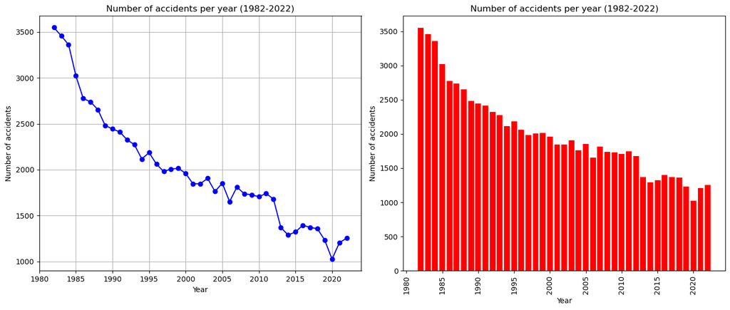

```python
# Comptage du nombre d'accidents par année
accidents_per_year = df['Event.Year'].value_counts().sort_index()

# Taille de la figure
plt.figure(figsize=(14, 6))

# 1. Graphique en ligne avec plt.plot
plt.subplot(1, 2, 1)
plt.plot(accidents_per_year.index, accidents_per_year.values, marker='o', linestyle='-', color='blue')
plt.title("Number of accidents per year (1982-2022)")
plt.xlabel("Year")
plt.ylabel("Number of accidents")
plt.grid(True)

# 2. Graphique en barres avec plt.bar
plt.subplot(1, 2, 2)
plt.bar(accidents_per_year.index, accidents_per_year.values, color='red')
plt.title("Number of accidents per year (1982-2022)")
plt.xlabel("Year")
plt.ylabel("Number of accidents")
plt.xticks(rotation=90)

plt.tight_layout()
plt.show()
```

Commentaire: Depuis 1982, le nombre d'accidents a fortement diminué, ce qui reflète des progrès notables en sécurité aérienne, réglementation, technologies, formation et gestion des risques dans le secteur.

Nous allons analyser le nombre de personnes impliquées dans des accidents d’aviation par année, afin de mieux comprendre l’ampleur des événements au fil du temps.

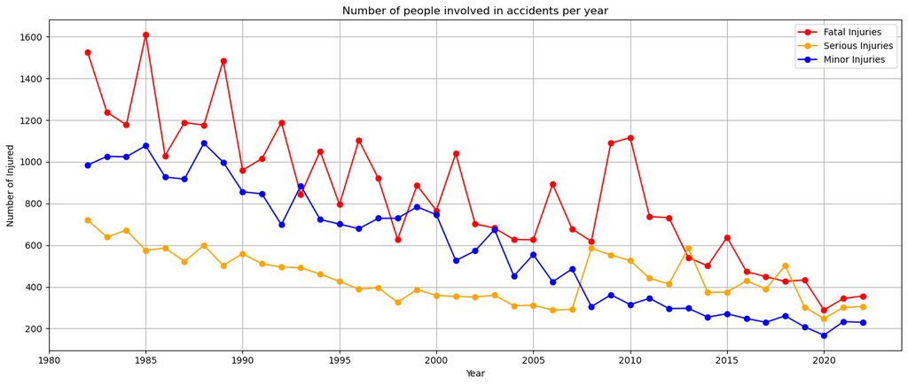

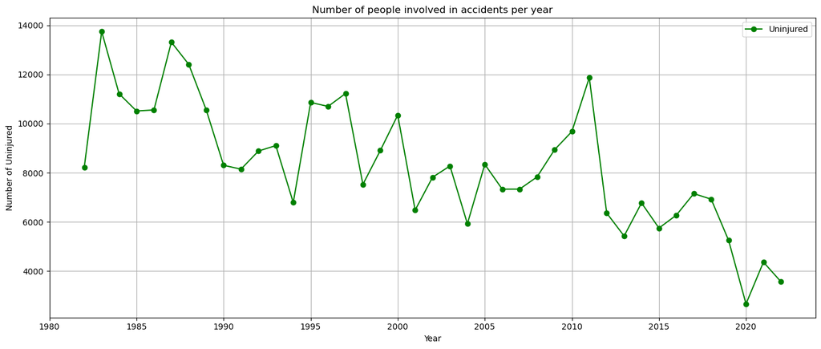

```python
# Groupement annuel des types de blessures
fatal_by_year = df.groupby('Event.Year')['Total.Fatal.Injuries'].sum()
serious_by_year = df.groupby('Event.Year')['Total.Serious.Injuries'].sum()
minor_by_year = df.groupby('Event.Year')['Total.Minor.Injuries'].sum()

# Groupement annuel des indemnes
uninjured_by_year = df.groupby('Event.Year')['Total.Uninjured'].sum()


# Premier graphique : blessures

plt.figure(figsize=(14, 6))
plt.plot(fatal_by_year.index, fatal_by_year.values, label='Fatal Injuries', color='red', marker='o')
plt.plot(serious_by_year.index, serious_by_year.values, label='Serious Injuries', color='orange', marker='o')
plt.plot(minor_by_year.index, minor_by_year.values, label='Minor Injuries', color='blue', marker='o')

plt.title("Number of people involved in accidents per year")
plt.xlabel("Year")
plt.ylabel("Number of Injured")
plt.legend()
plt.grid(True)
plt.tight_layout()
plt.show()

# Deuxième graphique : indemnes

plt.figure(figsize=(14, 6))
plt.plot(uninjured_by_year.index, uninjured_by_year.values, label='Uninjured', color='green', marker='o')

plt.title("Number of people involved in accidents per year")
plt.xlabel("Year")
plt.ylabel("Number of Uninjured")
plt.legend()
plt.grid(True)
plt.tight_layout()
plt.show()
```

Les courbes représentant le nombre de personnes blessées dans les accidents d’aviation présentent une pente globalement décroissante, traduisant une diminution progressive des blessés au fil des années. Il est également à noter que le nombre de personnes mortellement blessées a significativement diminué au cours des dix dernières années, ce qui témoigne d’une amélioration notable en matière de sécurité aérienne.

```
 Répartition des accidents selon l’objectif de vol
```

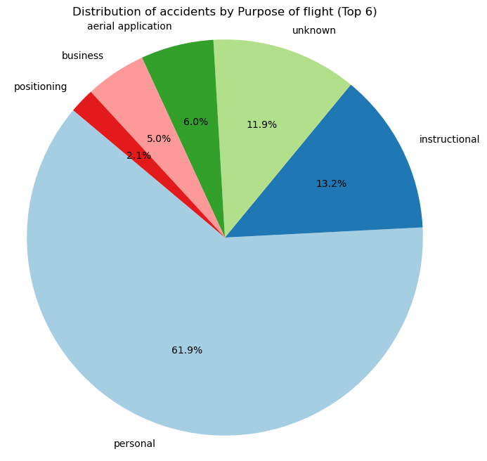

```python
# Compter les occurrences par objectif de vol (on limite aux 6 plus fréquents pour lisibilité)
purpose_counts = df['Purpose.of.flight'].value_counts().head(6)


plt.figure(figsize=(8, 8))

plt.pie(
    purpose_counts,                            # les valeurs à afficher
    labels=purpose_counts.index,               # les noms des catégories
    autopct='%1.1f%%',                         # affiche les pourcentages avec 1 décimale (ex : 32.5%)
    startangle=140,                            # angle de départ de la première tranche
    colors=plt.cm.Paired.colors                # gamme de couleurs pré-définie pour plus de clarté
)
plt.title("Distribution of accidents by Purpose of flight (Top 6)")
plt.axis('equal')  # Pour un cercle parfait
plt.show()
```

Ce graphique ci-dessus montre visuellement que les vols personnels et instructional(pédagogique) sont les plus concernés par les accidents.

Evolution annuelle du nombre de blessés (Fatal, Serious, Minor) et des indemnes par Objectif de vol.

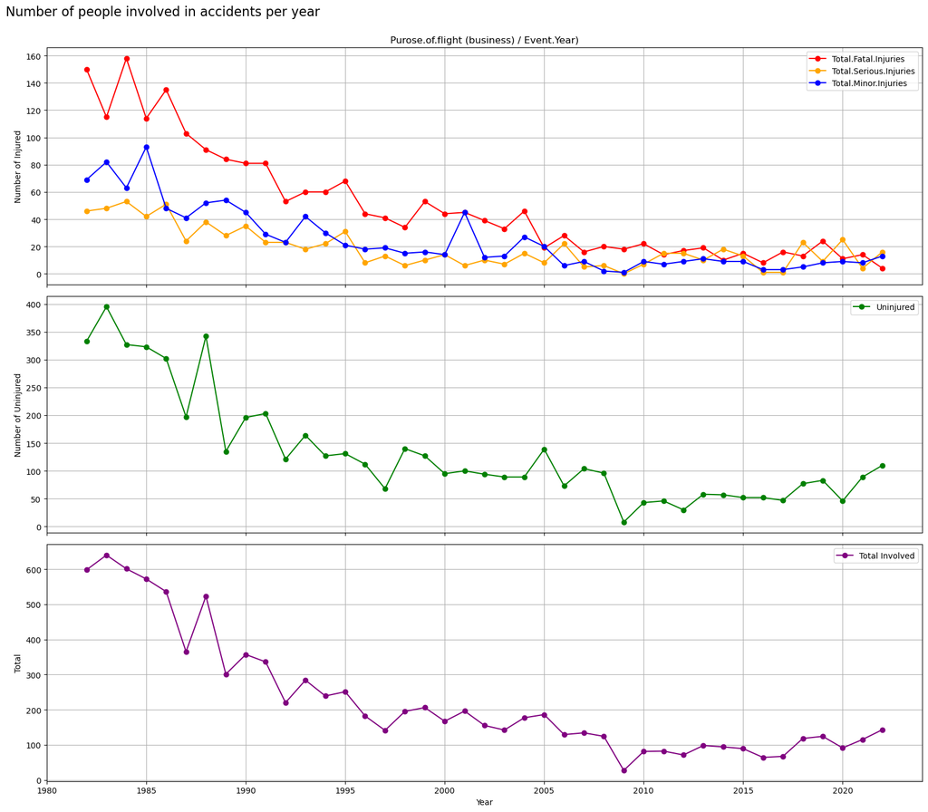

```python
# Filtrer uniquement les vols à objectif 'business'
df_business = df[df['Purpose.of.flight'] == 'business'].copy()

# Remplacer les valeurs manquantes par 0
cols = ['Total.Fatal.Injuries', 'Total.Serious.Injuries', 'Total.Minor.Injuries', 'Total.Uninjured']
df_business[cols] = df_business[cols].fillna(0)

# Calculer Total.Injuries
df_business['Total.Injuries'] = (
    df_business['Total.Fatal.Injuries'] +
    df_business['Total.Serious.Injuries'] +
    df_business['Total.Minor.Injuries']
)

# Calculer Total Involved (blessés + indemnes)
df_business['Total.Involved'] = df_business['Total.Injuries'] + df_business['Total.Uninjured']

# Agrégation annuelle
fatal_by_year = df_business.groupby('Event.Year')['Total.Fatal.Injuries'].sum()
serious_by_year = df_business.groupby('Event.Year')['Total.Serious.Injuries'].sum()
minor_by_year = df_business.groupby('Event.Year')['Total.Minor.Injuries'].sum()
uninjured_by_year = df_business.groupby('Event.Year')['Total.Uninjured'].sum()
total_involved_by_year = df_business.groupby('Event.Year')['Total.Involved'].sum()

# Création des graphiques avec un axe des années partagé
fig, axs = plt.subplots(3, 1, figsize=(16, 14), sharex=True)


# Grand titre:
plt.suptitle("Number of people involved in accidents per year", fontsize=16, x=0.0, y=0.999999, ha='left')

# Graphique 1 : Blessés
axs[0].plot(fatal_by_year.index, fatal_by_year.values, label='Total.Fatal.Injuries', color='red', marker='o')
axs[0].plot(serious_by_year.index, serious_by_year.values, label='Total.Serious.Injuries', color='orange', marker='o')
axs[0].plot(minor_by_year.index, minor_by_year.values, label='Total.Minor.Injuries', color='blue', marker='o')
axs[0].set_title("Purose.of.flight (business) / Event.Year)")
axs[0].set_ylabel("Number of Injured")
axs[0].legend()
axs[0].grid(True)

# Graphique 2 : Indemnes
axs[1].plot(uninjured_by_year.index, uninjured_by_year.values, label='Uninjured', color='green', marker='o')
axs[1].set_ylabel("Number of Uninjured")
axs[1].legend()
axs[1].grid(True)

# Graphique 3 : Total impliqués
axs[2].plot(total_involved_by_year.index, total_involved_by_year.values, label='Total Involved', color='purple', marker='o')
axs[2].set_xlabel("Year")
axs[2].set_ylabel("Total")
axs[2].legend()
axs[2].grid(True)

plt.tight_layout()
plt.show()
```

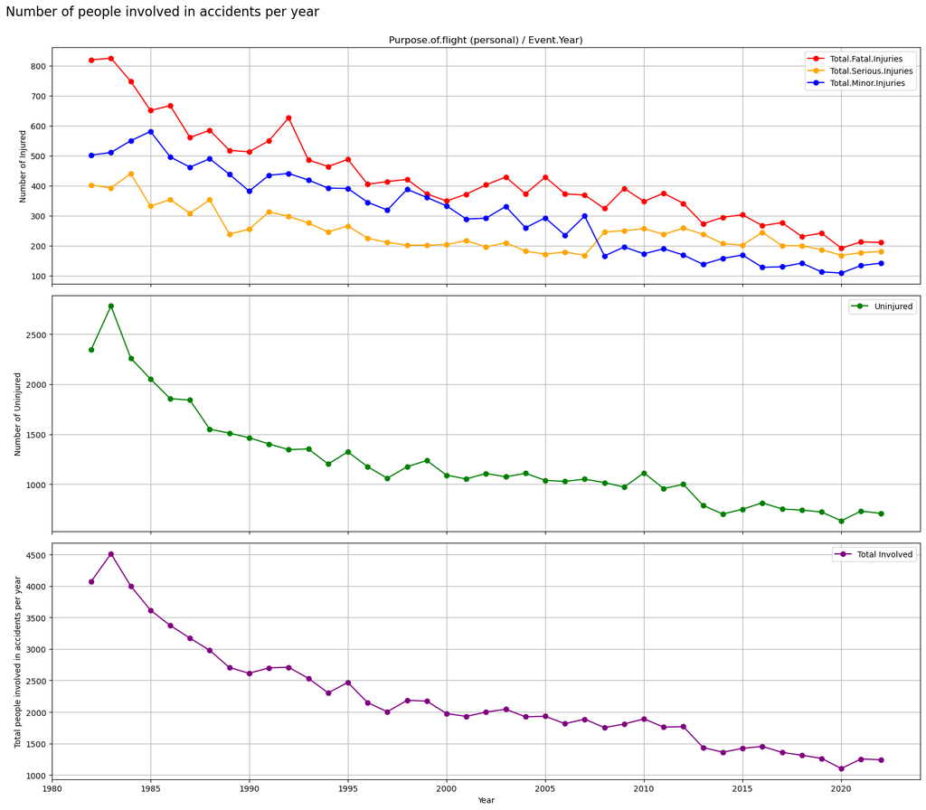

```python
# Filtrer uniquement les vols à objectif 'personal'
df_personal = df[df['Purpose.of.flight'] == 'personal'].copy()

# Remplacer les valeurs manquantes par 0
cols = ['Total.Fatal.Injuries', 'Total.Serious.Injuries', 'Total.Minor.Injuries', 'Total.Uninjured']
df_personal[cols] = df_personal[cols].fillna(0)

# Calculer Total.Injuries
df_personal['Total.Injuries'] = (
    df_personal['Total.Fatal.Injuries'] +
    df_personal['Total.Serious.Injuries'] +
    df_personal['Total.Minor.Injuries']
)

# Calculer Total Involved (blessés + indemnes)
df_personal['Total.Involved'] = df_personal['Total.Injuries'] + df_personal['Total.Uninjured']

# Agrégation annuelle
fatal_by_year = df_personal.groupby('Event.Year')['Total.Fatal.Injuries'].sum()
serious_by_year = df_personal.groupby('Event.Year')['Total.Serious.Injuries'].sum()
minor_by_year = df_personal.groupby('Event.Year')['Total.Minor.Injuries'].sum()
uninjured_by_year = df_personal.groupby('Event.Year')['Total.Uninjured'].sum()
total_involved_by_year = df_personal.groupby('Event.Year')['Total.Involved'].sum()

# Création des graphiques avec un axe des années partagé
fig, axs = plt.subplots(3, 1, figsize=(16, 14), sharex=True)


# Grand titre:
plt.suptitle("Number of people involved in accidents per year", fontsize=16, x=0.0, y=0.999999, ha='left')

# Graphique 1 : Blessés
axs[0].plot(fatal_by_year.index, fatal_by_year.values, label='Total.Fatal.Injuries', color='red', marker='o')
axs[0].plot(serious_by_year.index, serious_by_year.values, label='Total.Serious.Injuries', color='orange', marker='o')
axs[0].plot(minor_by_year.index, minor_by_year.values, label='Total.Minor.Injuries', color='blue', marker='o')
axs[0].set_title("Purpose.of.flight (personal) / Event.Year)")
axs[0].set_ylabel("Number of Injured")
axs[0].legend()
axs[0].grid(True)

# Graphique 2 : Indemnes
axs[1].plot(uninjured_by_year.index, uninjured_by_year.values, label='Uninjured', color='green', marker='o')
axs[1].set_ylabel("Number of Uninjured")
axs[1].legend()
axs[1].grid(True)

# Graphique 3 : Total impliqués
axs[2].plot(total_involved_by_year.index, total_involved_by_year.values, label='Total Involved', color='purple', marker='o')
axs[2].set_xlabel("Year")
axs[2].set_ylabel("Total people involved in accidents per year")
axs[2].legend()
axs[2].grid(True)

plt.tight_layout()
plt.show()
```

```python
# Examinons la colonne Broadphase.of.flight
df["Broad.phase.of.flight"].value_counts()
```

```
Broad.phase.of.flight
landing        15018
takeoff        12267
cruise         10050
maneuvering     7961
approach        6216
climb           1974
descent         1824
taxi            1777
go-around       1342
standing         857
unknown          539
other            111
Name: count, dtype: int64
```

On peut vite remarquer que les phases, landing; takeoff; cruise; maneuvering; approach sont les plus critiques

```
Affichons les top 5 phases de vol associées au plus grand nombre de décès
```

```python
# Regrouper par phase de vol et sommer les fatalités
fatalities_by_phase = df.groupby('Broad.phase.of.flight')['Total.Fatal.Injuries'].sum().reset_index()

# Trier et garder les 5 phases les plus mortelles
top5_fatalities = fatalities_by_phase.sort_values(by='Total.Fatal.Injuries', ascending=False).head(5)

# Afficher le DataFrame
print(top5_fatalities)
```

```
  Broad.phase.of.flight  Total.Fatal.Injuries
2                cruise                  5808
6           maneuvering                  5137
9               takeoff                  4241
0              approach                  3645
1                 climb                  1672
```

Le dataframe ci-dessus montre les 5 phases de vol associées au plus grand nombre de fatalités, les phases cruise et maneuvering sont les plus meurtrières (critiques)

```python
# Étape 1 : Grouper les fatalités par phase de vol
bubble_data = df.groupby('Broad.phase.of.flight')['Total.Fatal.Injuries'].sum().reset_index()

# Étape 2 : Garder les 5 phases avec le plus de fatalités
top5_bubble_data = bubble_data.sort_values(by='Total.Fatal.Injuries', ascending=False).head(5).reset_index(drop=True)

# Étape 3 : Créer des positions x/y fictives pour espacer les bulles visuellement
angle = np.linspace(0, 2*np.pi, len(top5_bubble_data), endpoint=False)
radius = 2
top5_bubble_data['x'] = radius * np.cos(angle)
top5_bubble_data['y'] = radius * np.sin(angle)

# Étape 4 : Créer le bubble chart
fig = px.scatter(
    top5_bubble_data,
    x="x",
    y="y",
    size="Total.Fatal.Injuries",
    color="Broad.phase.of.flight",
    hover_name="Broad.phase.of.flight",
    size_max=120,
    title="Top 5 Broad.phase.of.flight by Fatalities"
)


fig.update_layout(
    showlegend=True,
    xaxis=dict(visible=False),
    yaxis=dict(visible=False),
    plot_bgcolor='white',
    margin=dict(t=60, b=40, l=20, r=20),
)

fig.show()
```

[interactive chart not shown]

L’analyse montre que la phase « Cruise » (croisière) est la plus meurtrière parmi les différentes phases de vol. C’est durant cette phase que l’on enregistre le plus grand nombre de décès liés aux accidents d’aviation.

```
 Détermination des Make_Models les moins risqués : approche en deux temps
```

L’identification des avions les moins risqués repose sur une analyse en deux dimensions complémentaires. En effet, se baser sur un seul critère peut conduire à des conclusions biaisées. Voici les deux axes d’analyse retenus :

1. Analyse selon le nombre total de personnes indemnes

Dans un premier temps, nous groupons les données par Make_Model et classons les aéronefs selon le nombre total de personnes indemnes lors des accidents. L’hypothèse ici est que plus un avion compte de personnes sorties indemnes, plus il est potentiellement sûr. Nous allons ensuite calculer un ratio de risque comme suit :

Risk_Ratio = Nombre total de blessés / (Nombre total de blessés + Nombre total d’indemnes)

Ce ratio permet d’estimer, en moyenne, la probabilité qu’un accident entraîne des blessures plutôt qu’aucune.

✅ Avantage : Cette approche met en avant les avions qui protègent le mieux leurs occupants. ⚠️ Limite : Certains avions peuvent apparaître comme peu risqués simplement parce qu’ils sont rarement utilisés ou impliqués dans des accidents mineurs.

2. Analyse selon la fréquence d’implication dans des accidents

Dans un second temps, nous regardons les modèles d'avions les plus fréquemment impliqués dans des accidents (c’est-à-dire avec un grand nombre d’occurrences). Cela permet d’évaluer la robustesse statistique des données.

Cependant, un grand nombre d’occurrences ne signifie pas nécessairement un risque élevé. En réalité, cela peut simplement refléter une forte popularité ou une large utilisation du modèle. Par exemple, les modèles Cessna sont très présents dans les bases de données d'accidents, car ils sont massivement utilisés dans l'aviation légère.

Cela permet de déterminer si, à fréquence d’usage élevée, un modèle reste globalement sûr ou présente un risque relatif plus élevé.

Affichons les top10 Make_Model avec le plus grand nombre de personnes indemnes, on affiche aussi dans le dataframe le nombre de personne blesse et le nombre de fois ces Make_Models sont impliques dans des accidents (occurrence).

```python
# Étape 1 : Créer une nouvelle colonne 'Total.Injuries' dans le DataFrame d'origine
df['Total.Injuries'] = df[['Total.Serious.Injuries', 'Total.Minor.Injuries', 'Total.Fatal.Injuries']].sum(axis=1)

# Étape 2 : Regrouper par Make et Model, et agréger
summary_df = df.groupby(['Make', 'Model']).agg(
    Total_Uninjured=('Total.Uninjured', 'sum'),
    Total_Injuries=('Total.Injuries', 'sum'),
    Occurrences=('Make', 'size')  # ou 'size', selon ta logique
).reset_index()

# Étape 3 : Trier par Total_Uninjured décroissant
summary_df = summary_df.sort_values(by='Total_Uninjured', ascending=False)

# Étape 4 : Afficher les 10 premiers
print(summary_df.head(10))
```

```
                    Make     Model  Total_Uninjured  Total_Injuries  \
2891              boeing       737             9504             536
10604  mcdonnell douglas  dc-10-10             5840             458
3074              boeing       767             4225              70
3032              boeing   747-422             3770              52
2842              boeing   727-200             3630              55
3030              boeing   747-400             3492               9
10608  mcdonnell douglas  dc-10-30             3168              69
3061              boeing   757-232             3139              48
2936              boeing   737-300             3135              87
10637  mcdonnell douglas   dc-9-82             3009             174

       Occurrences
2891           122
10604           35
3074            38
3032            12
2842            36
3030            13
10608           15
3061            22
2936            34
10637           28
```

Pour ces top10 Make_Model, nous allons determiner:

nombre moyen de blessés par accident

nombre moyen d’indemnes par accident

ratio de risque (Risk_Ratio)

```python
# Liste des Make_Model à conserver selon ton tableau top10 Make_Model
top10_models = [
    ('boeing', '737'),
    ('mcdonnell douglas', 'dc-10-10'),
    ('boeing', '767'),
    ('boeing', '747-422'),
    ('boeing', '727-200'),
    ('boeing', '747-400'),
    ('mcdonnell douglas', 'dc-10-30'),
    ('boeing', '757-232'),
    ('boeing', '737-300'),
    ('mcdonnell douglas', 'dc-9-82')
]


# Filtrer le DataFrame selon la liste
filtered_df = summary_df[summary_df[['Make', 'Model']].apply(tuple, axis=1).isin(top10_models)].copy()

# Calculs complémentaires
filtered_df['Injured_per_Accident'] = filtered_df['Total_Injuries'] / filtered_df['Occurrences']
filtered_df['Uninjured_per_Accident'] = filtered_df['Total_Uninjured'] / filtered_df['Occurrences']
filtered_df['Risk_Ratio'] = filtered_df['Total_Injuries'] / (
    filtered_df['Total_Injuries'] + filtered_df['Total_Uninjured']
)

# Trier par Risk_Ratio croissant
filtered_df = filtered_df.sort_values(by='Risk_Ratio')

# Afficher le résultat
print(filtered_df[['Make', 'Model', 'Total_Uninjured', 'Total_Injuries', 'Occurrences',
                   'Injured_per_Accident', 'Uninjured_per_Accident', 'Risk_Ratio']])
```

```
                    Make     Model  Total_Uninjured  Total_Injuries  \
3030              boeing   747-400             3492               9
3032              boeing   747-422             3770              52
2842              boeing   727-200             3630              55
3061              boeing   757-232             3139              48
3074              boeing       767             4225              70
10608  mcdonnell douglas  dc-10-30             3168              69
2936              boeing   737-300             3135              87
2891              boeing       737             9504             536
10637  mcdonnell douglas   dc-9-82             3009             174
10604  mcdonnell douglas  dc-10-10             5840             458

       Occurrences  Injured_per_Accident  Uninjured_per_Accident  Risk_Ratio
3030            13              0.692308              268.615385    0.002571
3032            12              4.333333              314.166667    0.013605
2842            36              1.527778              100.833333    0.014925
3061            22              2.181818              142.681818    0.015061
3074            38              1.842105              111.184211    0.016298
10608           15              4.600000              211.200000    0.021316
2936            34              2.558824               92.205882    0.027002
2891           122              4.393443               77.901639    0.053386
10637           28              6.214286              107.464286    0.054665
10604           35             13.085714              166.857143    0.072721
```

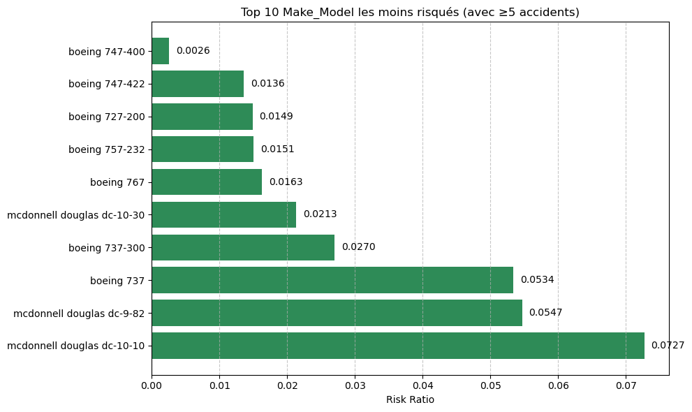

```python
# Top 10 les moins risqués
top10_risk = filtered_df[['Make', 'Model', 'Risk_Ratio']].sort_values(by='Risk_Ratio').head(10).copy()
top10_risk['Make_Model'] = top10_risk['Make'] + ' ' + top10_risk['Model']

# Graphique
plt.figure(figsize=(10, 6))
bars = plt.barh(
    top10_risk['Make_Model'],
    top10_risk['Risk_Ratio'],
    color='seagreen'
)

# Annoter les valeurs
for bar in bars:
    width = bar.get_width()
    plt.text(width + 0.001, bar.get_y() + bar.get_height()/2,
             f'{width:.4f}', va='center')

plt.xlabel('Risk Ratio')
plt.title('Top 10 Make_Model les moins risqués (avec ≥5 accidents)')
plt.gca().invert_yaxis()
plt.grid(axis='x', linestyle='--', alpha=0.7)
plt.tight_layout()
plt.show()
```

Boeing 747-400 Modèle le moins risqué selon le Risk_Ratio (0.0026, soit 0.26 %).

Ce très faible taux indique qu’il y a moins d’1 blessé tous les 100 passagers impliqués.

Avec 13 occurrences, les données sont suffisantes pour affirmer la robustesse de ce modèle.

Il combine haute capacité (près de 270 passagers indemnes/accident) et faible taux de blessure.

2. Boeing 747-422

Deuxième modèle le plus sûr (Risk_Ratio ≈ 1.36 %).

Même famille que le 747-400, avec une moyenne encore plus élevée d’indemnes par accident.

Bien qu’un peu plus de blessés par événement que le 747-400, son excellent ratio sécurité/passager confirme la fiabilité des Boeing 747.

3. Boeing 727-200

Troisième position (Risk_Ratio ≈ 1.49 %), avec le plus grand nombre d’occurrences parmi les trois (36).

Bonne régularité en termes de sécurité : peu de blessés par accident (1.5) et plus de 100 indemnes en moyenne.

Pour ces 10 modèles d'avions (Make_Model), nous allons determiner leurs caractéristiques techniques et structurelles.

En particulier, nous allons déterminer pour chacun de ces modèles :

Le type de moteur utilisé (Engine.Type)

Le nombre de moteurs installés (Number.of.Engines)

Si l’appareil a été construit de manière artisanale ou non (Amateur.Built)

Note: On utilise le mode pour extraire la valeur la plus fréquente lorsqu’un même modèle d’avion apparaît avec plusieurs configurations. Cela permet d’identifier la configuration la plus représentative (type de moteur, nombre de moteurs, etc.) sans être influencé par des variations ou erreurs isolées.

En effet, un même Make_Model peut apparaître dans le jeu de données avec de légères variations dans les colonnes comme :

Engine.Type (ex : "turbo tan", "turbo jet"),

Number.of.Engines (ex : parfois 2, parfois 4 si erreurs de saisie),

Amateur.Built (ex : "yes", "no").

Plutôt que de prendre la première valeur ou la moyenne (non pertinente pour du texte), le mode permet de retenir celle qui revient le plus souvent, ce qui reflète la configuration la plus typique ou la plus probable pour ce modèle d’avion.

C’est donc une méthode fiable pour résumer les caractéristiques dominantes d’un type d'appareil.

```python
# 1. Recréer Make_Model dans df pour faciliter la jointure
df['Make_Model'] = df['Make'].str.strip().str.lower() + ' ' + df['Model'].str.strip().str.lower()

# 2. Définir la liste des top10 Make_Model
top10_models = [
    ('boeing', '737'),
    ('mcdonnell douglas', 'dc-10-10'),
    ('boeing', '767'),
    ('boeing', '747-422'),
    ('boeing', '727-200'),
    ('boeing', '747-400'),
    ('mcdonnell douglas', 'dc-10-30'),
    ('boeing', '757-232'),
    ('boeing', '737-300'),
    ('mcdonnell douglas', 'dc-9-82')
]

# 3. Générer la liste des Make_Model au bon format
top10_keys = [make.strip().lower() + ' ' + model.strip().lower() for make, model in top10_models]

# 4. Filtrer le DataFrame original
filtered = df[df['Make_Model'].isin(top10_keys)]

# 5. Grouper et utiliser mode() pour les valeurs typiques
result = filtered.groupby('Make_Model').agg({
    'Number.of.Engines': lambda x: x.mode().iloc[0] if not x.mode().empty else None,
    'Engine.Type': lambda x: x.mode().iloc[0] if not x.mode().empty else None,
    'Amateur.Built': lambda x: x.mode().iloc[0] if not x.mode().empty else None
}).reset_index()

# 6. Afficher le résultat
print(result)
```

```
                   Make_Model  Number.of.Engines Engine.Type Amateur.Built
0              boeing 727-200                  3   turbo fan            no
1                  boeing 737                  2     unknown            no
2              boeing 737-300                  2   turbo fan            no
3              boeing 747-400                  4   turbo fan            no
4              boeing 747-422                  4   turbo fan            no
5              boeing 757-232                  2   turbo fan            no
6                  boeing 767                  2   turbo fan            no
7  mcdonnell douglas dc-10-10                  3   turbo fan            no
8  mcdonnell douglas dc-10-30                  3   turbo fan            no
9   mcdonnell douglas dc-9-82                  2   turbo fan            no
```

Commentaire: Nombre de moteurs Tous les modèles sont équipés de 2 à 4 moteurs, ce qui confirme leur conception comme avions multimoteurs. Avoir plusieurs moteurs améliore la sécurité en vol, notamment en cas de défaillance partielle.

Type de moteur La quasi-totalité des avions utilisent des moteurs de type turbo fan, à l'exception d'un cas de type "unknown" (inconnu). Les turbo fans sont largement reconnus pour leur efficacité à haute altitude, leur fiabilité et leur performance sur les vols commerciaux.

Construction par des amateurs Tous ces modèles ont Amateur.Built = 'no', ce qui signifie qu'ils ont été construits par des professionnels qualifiés, selon des normes industrielles rigoureuses. Cela réduit considérablement les risques d'erreurs de fabrication ou d’entretien.

```
 Affichons les top10 Make_Model avec le plus grand nombre d'occurrences, on affiche aussi dans le dataframe le nombre de personne blessees.
```

```python
# Etape 1 :Regrouper par Make et Model, et agréger les valeurs
summary_df = df.groupby(['Make', 'Model']).agg(
    Total_Uninjured=('Total.Uninjured', 'sum'),
    Total_Injured=('Total.Injuries', 'sum'),
    Occurrences=('Make', 'size')  # Nombre total d'incidents
).reset_index()

# Étape 3 : Trier par Occurrences (décroissant pour voir les plus fréquents)
summary_df = summary_df.sort_values(by='Occurrences', ascending=False)

# Étape 4 : Afficher les 10 premiers Make_Model
print(summary_df.head(10))
```

```
         Make      Model  Total_Uninjured  Total_Injured  Occurrences
4091   cessna        152             2236            935         2285
4115   cessna        172             2165            959         1652
4164   cessna       172n             1308            904         1125
12358   piper  pa-28-140              826            957          912
4064   cessna        150              738            416          795
4162   cessna       172m             1037            636          770
4167   cessna       172p              836            513          667
4197   cessna        180              973            243          611
4220   cessna        182              825            443          609
4090   cessna       150m              543            304          574
```

```python
# Liste des Make_Model à conserver selon ton tableau top10 Make_Model
top10_models = [
    ('cessna', '152'),
    ('cessna', '172'),
    ('cessna', '172n'),
    ('piper', 'pa-28-140 '),
    ('cessna', '150'),
    ('cessna', '172m'),
    ('cessna', '172p'),
    ('cessna', '180'),
    ('boeing', '182'),
    ('cessna', '150m')
]

# Correction d'éventuels espaces indésirables dans la colonne 'Make'
summary_df['Make'] = summary_df['Make'].str.strip()

# Filtrer le DataFrame selon la liste
filtered_df = summary_df[summary_df[['Make', 'Model']].apply(tuple, axis=1).isin(top10_models)].copy()

# Calculs complémentaires
filtered_df['Injured_per_Accident'] = filtered_df['Total_Injured'] / filtered_df['Occurrences']
filtered_df['Uninjured_per_Accident'] = filtered_df['Total_Uninjured'] / filtered_df['Occurrences']
filtered_df['Risk_Ratio'] = filtered_df['Total_Injured'] / (
    filtered_df['Total_Injured'] + filtered_df['Total_Uninjured']
)

# Trier par Risk_Ratio croissant
filtered_df = filtered_df.sort_values(by='Risk_Ratio')

# Afficher le résultat
print(filtered_df[['Make', 'Model', 'Total_Uninjured', 'Total_Injured', 'Occurrences',
                   'Injured_per_Accident', 'Uninjured_per_Accident', 'Risk_Ratio']])
```

```
        Make Model  Total_Uninjured  Total_Injured  Occurrences  \
4197  cessna   180              973            243          611
4091  cessna   152             2236            935         2285
4115  cessna   172             2165            959         1652
4090  cessna  150m              543            304          574
4064  cessna   150              738            416          795
4162  cessna  172m             1037            636          770
4167  cessna  172p              836            513          667
4164  cessna  172n             1308            904         1125

      Injured_per_Accident  Uninjured_per_Accident  Risk_Ratio
4197              0.397709                1.592471    0.199836
4091              0.409190                0.978556    0.294860
4115              0.580508                1.310533    0.306978
4090              0.529617                0.945993    0.358914
4064              0.523270                0.928302    0.360485
4162              0.825974                1.346753    0.380155
4167              0.769115                1.253373    0.380282
4164              0.803556                1.162667    0.408680
```

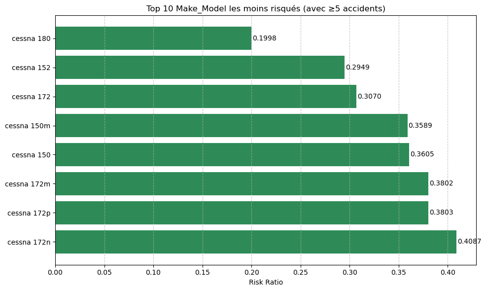

```python
# Top 10 les moins risqués
top10_risk = filtered_df[['Make', 'Model', 'Risk_Ratio']].sort_values(by='Risk_Ratio').head(10).copy()
top10_risk['Make_Model'] = top10_risk['Make'] + ' ' + top10_risk['Model']

# Graphique
plt.figure(figsize=(10, 6))
bars = plt.barh(
    top10_risk['Make_Model'],
    top10_risk['Risk_Ratio'],
    color='seagreen'
)

# Annoter les valeurs
for bar in bars:
    width = bar.get_width()
    plt.text(width + 0.001, bar.get_y() + bar.get_height()/2,
             f'{width:.4f}', va='center')

plt.xlabel('Risk Ratio')
plt.title('Top 10 Make_Model les moins risqués (avec ≥5 accidents)')
plt.gca().invert_yaxis()
plt.grid(axis='x', linestyle='--', alpha=0.7)
plt.tight_layout()
plt.show()
```

```python
# 1. Créer Make_Model dans le DataFrame pour faciliter l'identification
df['Make_Model'] = df['Make'].str.strip().str.lower() + ' ' + df['Model'].str.strip().str.lower()

# 2. Liste des top 10 Make_Model extraits de votre résultat (normalisés en minuscules)
top10_models = [
    'cessna 152',
    'cessna 172',
    'cessna 172n',
    'piper pa-28-140',
    'cessna 150',
    'cessna 172m',
    'cessna 172p',
    'cessna 180',
    'cessna 182',
    'cessna 150m'
]

# 3. Filtrer le DataFrame pour ne garder que les lignes correspondant aux Make_Models sélectionnés
filtered = df[df['Make_Model'].isin(top10_models)]

# 4. Grouper et récupérer la valeur la plus fréquente (mode) pour chaque caractéristique
result = filtered.groupby('Make_Model').agg({
    'Number.of.Engines': lambda x: x.mode().iloc[0] if not x.mode().empty else None,
    'Engine.Type': lambda x: x.mode().iloc[0] if not x.mode().empty else None,
    'Amateur.Built': lambda x: x.mode().iloc[0] if not x.mode().empty else None
}).reset_index()

# 5. Afficher le résultat
print(result)
```

```
        Make_Model  Number.of.Engines    Engine.Type Amateur.Built
0       cessna 150                  1  reciprocating            no
1      cessna 150m                  1  reciprocating            no
2       cessna 152                  1  reciprocating            no
3       cessna 172                  1  reciprocating            no
4      cessna 172m                  1  reciprocating            no
5      cessna 172n                  1  reciprocating            no
6      cessna 172p                  1  reciprocating            no
7       cessna 180                  1  reciprocating            no
8       cessna 182                  1  reciprocating            no
9  piper pa-28-140                  1  reciprocating            no
```

```
Remarque sur les Top 10 Make_Models selon le critère des occurrences
```

Les 10 Make_Models les moins risqués selon le critère du nombre d’occurrences d’accidents sont tous :

Monomoteurs (1 seul moteur),

Équipés de moteurs à pistons (reciprocating),

Construits de manière professionnelle (pas d’amateur).

Cela reflète principalement leur forte présence dans l’aviation légère et leur usage fréquent en formation, ce qui explique leur surreprésentation dans les statistiques.

Comparaison avec les modèles les plus sûrs selon le nombre de personnes indemnes À l’inverse, les Make_Models identifiés comme les plus fiables selon le critère du nombre de personnes indemnes sont :

Multimoteurs (2 à 4 moteurs),

Dotés de moteurs turbo fan, reconnus pour leur puissance, fiabilité et performance en vol commercial,

Professionnellement construits, adaptés aux standards de l’aviation civile.

Conclusion Les modèles évalués selon le nombre de personnes indemnes apparaissent plus fiables sur le plan technique, grâce à leur motorisation plus sûre et redondante. En revanche, les modèles fréquents dans les accidents ne sont pas nécessairement dangereux, mais souvent surutilisés dans des contextes à risque (formation, vols courts, aviation légère).

```
           Les Top10 Make_Models les plus risques
```

```python
# Étape 1 : Créer une nouvelle colonne 'Total.Injuries' dans le DataFrame d'origine
df['Total.Injuries'] = df[['Total.Serious.Injuries', 'Total.Minor.Injuries', 'Total.Fatal.Injuries']].sum(axis=1)

# Étape 2 : Regrouper par Make et Model, et agréger
summary_df = df.groupby(['Make', 'Model']).agg(
    Total_Uninjured=('Total.Uninjured', 'sum'),
    Total_Injuries=('Total.Injuries', 'sum'),
    Occurrences=('Make', 'size')  # ou 'size', selon ta logique
).reset_index()

# Étape 3 : Trier par Total_Uninjured décroissant
summary_df = summary_df.sort_values(by='Total_Injuries', ascending=False)

# Étape 4 : Afficher les 10 premiers
print(summary_df.head(10))
```

```
         Make      Model  Total_Uninjured  Total_Injuries  Occurrences
4115   cessna        172             2165             959         1652
12358   piper  pa-28-140              826             957          912
4091   cessna        152             2236             935         2285
4164   cessna       172n             1308             904         1125
12375   piper  pa-28-181              605             639          505
4162   cessna       172m             1037             636          770
12368   piper  pa-28-180              568             583          558
2302     bell       206b              560             564          487
2891   boeing        737             9504             536          122
4167   cessna       172p              836             513          667
```

Calcul du Risk_Ration

```python
# Liste des Make_Model à conserver selon ton tableau top10 Make_Model
top10_models = [
    ('cessna', '172'),
    ('piper', 'pa-28-140'),
    ('cessna', '152'),
    ('cessna', '172n'),
    ('piper', 'pa-28-181'),
    ('cessna', '172m'),
    ('piper', 'pa-28-181 '),
    ('bell', '206b'),
    ('boeing', '737'),
    ('cessna', '172p')
]


# Filtrer le DataFrame selon la liste
filtered_df = summary_df[summary_df[['Make', 'Model']].apply(tuple, axis=1).isin(top10_models)].copy()

# Calculs complémentaires
filtered_df['Injured_per_Accident'] = filtered_df['Total_Injuries'] / filtered_df['Occurrences']
filtered_df['Uninjured_per_Accident'] = filtered_df['Total_Uninjured'] / filtered_df['Occurrences']
filtered_df['Risk_Ratio'] = filtered_df['Total_Injuries'] / (
    filtered_df['Total_Injuries'] + filtered_df['Total_Uninjured']
)

# Trier par Risk_Ratio croissant
filtered_df = filtered_df.sort_values(by='Risk_Ratio', ascending=False)

# Afficher le résultat
print(filtered_df[['Make', 'Model', 'Total_Uninjured', 'Total_Injuries', 'Occurrences',
                   'Injured_per_Accident', 'Uninjured_per_Accident', 'Risk_Ratio']])
```

```
         Make      Model  Total_Uninjured  Total_Injuries  Occurrences  \
12358   piper  pa-28-140            826.0           957.0          912
12375   piper  pa-28-181            605.0           639.0          505
2302     bell       206b            560.0           564.0          487
4164   cessna       172n           1308.0           904.0         1125
4167   cessna       172p            836.0           513.0          667
4162   cessna       172m           1037.0           636.0          770
4115   cessna        172           2165.0           959.0         1652
4091   cessna        152           2236.0           935.0         2285
2891   boeing        737           9504.0           536.0          122

       Injured_per_Accident  Uninjured_per_Accident  Risk_Ratio
12358              1.049342                0.905702    0.536736
12375              1.265347                1.198020    0.513666
2302               1.158111                1.149897    0.501779
4164               0.803556                1.162667    0.408680
4167               0.769115                1.253373    0.380282
4162               0.825974                1.346753    0.380155
4115               0.580508                1.310533    0.306978
4091               0.409190                0.978556    0.294860
2891               4.393443               77.901639    0.053386
```

[figure not shown]

```python
# Étape 1 : Préparer les données (tri décroissant)
top10_most_risky = filtered_df[['Make', 'Model', 'Risk_Ratio']].sort_values(by='Risk_Ratio', ascending=False).head(10).copy()
top10_most_risky['Make_Model'] = top10_most_risky['Make'] + ' ' + top10_most_risky['Model']

# Étape 2 : Tracer le graphique
plt.figure(figsize=(10, 6))
bars = plt.barh(
    top10_most_risky['Make_Model'],
    top10_most_risky['Risk_Ratio'],
    color='firebrick'
)

# Étape 3 : Ajouter les annotations
for bar in bars:
    width = bar.get_width()
    plt.text(width + 0.005, bar.get_y() + bar.get_height()/2,
             f'{width:.4f}', va='center')

# Étape 4 : Mise en forme
plt.xlabel('Risk Ratio')
plt.title('Top 10 Make_Model les plus risqués (avec ≥5 accidents)')
plt.gca().invert_yaxis()  # Afficher le plus risqué en haut
plt.grid(axis='x', linestyle='--', alpha=0.7)
plt.tight_layout()
plt.show()
```

Non construits par des amateurs (Amateur.Built = no), donc conformes aux standards professionnels.

Moteurs à pistons = performance limitée Moins puissants et moins fiables sur longues distances ou en haute altitude, surtout s’ils sont mal entretenus.

Usage fréquent en formation = surreprésentation Ces modèles sont très utilisés par des pilotes en formation, ce qui explique en partie leur taux d'accidents élevé, non pas par défaut de conception, mais par contexte d’utilisation.

### Business Recommendation 1

✅ Recommandations :

Intensifier la formation des pilotes pour ces phases (simulateurs réalistes, entraînement en conditions extrêmes).

Renforcer l’automatisation et les aides à la décision (alertes automatisées, meilleure intégration des données météo).

Surveiller en temps réel la performance des pilotes et systèmes durant ces phases via des systèmes embarqués.

### Business Recommendation 2

Modèles d’aéronefs à privilégier (meilleure sécurité observée) Modèles recommandés : Pour les vols commerciaux, optez pour des modèles comme: boeing 747-400; boeing 757-232; boeing 767; mcdonnell douglas dc-10-30 et boeing 737-300, ils sont multimoteurs, propulsés par des turbo fans, et non construits par des amateurs.

Ces caractéristiques sont des indicateurs fiables de sécurité, car elles reflètent des standards de conception professionnelle, de redondance mécanique et de performance moteur.

Pour l’apprentissage ou les petits trajets privés, les Cessna 152/172 restent de bonnes options, à condition que l'entretien soit rigoureux et que les vols se déroulent dans des conditions météorologiques favorables.

### Business Recommendation 3

Modèles à éviter pour les vols à haut risque ou longues distances : piper pa-28-140; piper pa-28-181; bell 206b; cessna 172n; cessna 172p

## Conclusion

Conclusion: L’analyse montre que la sécurité aérienne a considérablement progressé depuis 1982, avec une baisse notable du nombre d’accidents et de blessés. Cette amélioration est le fruit de plusieurs facteurs : avancées technologiques, renforcement des réglementations, amélioration de la formation des pilotes, meilleure gestion des risques et maintenance plus rigoureuse des aéronefs.

Cependant, des zones de vigilance subsistent, notamment en fonction du type de vol, de la phase de vol, du type d’appareil et des conditions météorologiques. L'analyse approfondie permet ainsi de dégager des recommandations utiles pour renforcer encore la sécurité.